# Practical Machine Learning Course Project Report

### Project Introduction

Using devices such as Jawbone Up, Nike FuelBand, and Fitbit it is now possible to collect a large amount of data about personal activity relatively inexpensively. These type of devices are part of the quantified self movement ? a group of enthusiasts who take measurements about themselves regularly to improve their health, to find patterns in their behavior, or because they are tech geeks. One thing that people regularly do is quantify how much of a particular activity they do, but they rarely quantify how well they do it. In this project, your goal will be to use data from accelerometers on the belt, forearm, arm, and dumbell of 6 participants. They were asked to perform barbell lifts correctly and incorrectly in 5 different ways.

The links for the training and test data are given below:

- https://d396qusza40orc.cloudfront.net/predmachlearn/pml-training.csv
- https://d396qusza40orc.cloudfront.net/predmachlearn/pml-testing.csv

### Load data

First, load data and do some simply cleaning, such as unifying “NA” strings, and remove the variables with all NAs. After that, slice the “training” data further into a training and a testing sections.

```
## Cleaned data sets dimensions:
```

```
## [1] 19622    59
```

```
## [1] 20 59
```

### Prediction Methods

We will be comparing two different methods: random forest and boosting.

#### 1. Random forests model

```
## Accuracy of random forest model:  0.9994902
```

### 2. Boosting model

```
## Accuracy of boosting model:  0.9972812
```

### Final prediction

From the accuracy and plots comparison, the random forest model has a bit advantages over the boosting model, albeit the execution time is significantly longer.

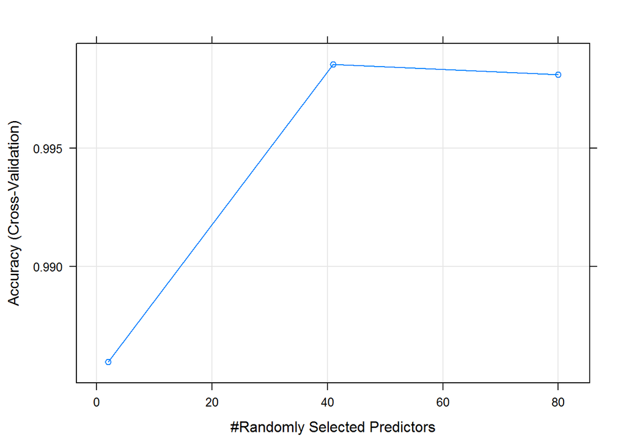

```r
plot(fit_rf)
```

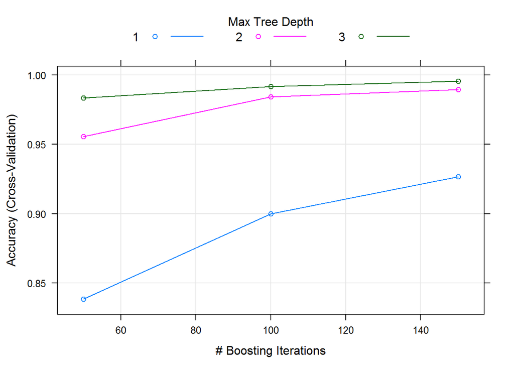

```r
plot(fit_gbm)
```

```r
# Final model
fit_rf$finalModel
```

```
##
## Call:
##  randomForest(x = x, y = y, mtry = param$mtry, verbose = ..1)
##                Type of random forest: classification
##                      Number of trees: 500
## No. of variables tried at each split: 41
##
##         OOB estimate of  error rate: 0.07%
## Confusion matrix:
##      A    B    C    D    E  class.error
## A 3906    0    0    0    0 0.0000000000
## B    0 2657    1    0    0 0.0003762227
## C    0    2 2393    1    0 0.0012520868
## D    0    0    2 2249    1 0.0013321492
## E    0    0    0    2 2523 0.0007920792
```